# Case Study: Oscar Winner Ages

Elise Haylett

Wednesday, February 12, 2020 @ 01:29 PM

Load the package(s) you will need.

```r
# Put your code here.
library(tidyverse)
library(dplyr)
```

In January 2007, Entertainment Weekly magazine featured a [cover story](http://www.simplystreep.com/gallery/displayimage.php?album=345&pid=25019#top_display_media) about three Academy Award nominees for Best Actress (Meryl Streep, Judy Densch, and Helen Mirren), with a cover tagline that proclaimed “The Silver Foxes Rule!” This theme continued inside, with the article focusing in large part on how old these three women were, relative to previous winners, and the perceived Hollywood bias in favor of younger actresses. This discussion persists in one form or another to this day. (data: oscarages.csv)

1. Use `read_csv` to import the data, then `glimpse` and `head` to display the dataset structure.

```r
oscarages <- read_csv(file = url("https://raw.githubusercontent.com/STAT-JET-ASU/Datasets/master/Instructor/oscarages.csv"))
glimpse(oscarages)
```

```
Observations: 354
Variables: 6
$ ceremony <dbl> 1929, 1929, 1930, 1930, 1930, 1930, 1931, 1931, 1932, 1932, …
$ decade   <chr> "1920s-30s", "1920s-30s", "1920s-30s", "1920s-30s", "1920s-3…
$ category <chr> "Best Actor", "Best Actress", "Best Actor", "Best Actor", "B…
$ name     <chr> "Emil Jannings", "Janet Gaynor", "Warner Baxter", "George Ar…
$ age      <dbl> 44, 22, 41, 62, 37, 30, 53, 62, 35, 47, 32, 34, 26, 34, 31, …
$ title    <chr> "The Last Command, The way of All Flesh", "7th Heaven, Stree…
```

```r
head(oscarages)
```

```
# A tibble: 6 x 6
  ceremony decade   category    name        age title
     <dbl> <chr>    <chr>       <chr>     <dbl> <chr>
1     1929 1920s-3… Best Actor  Emil Jan…    44 The Last Command, The way of Al…
2     1929 1920s-3… Best Actre… Janet Ga…    22 7th Heaven, Street Angel, Sunri…
3     1930 1920s-3… Best Actor  Warner B…    41 In Old Arizona
4     1930 1920s-3… Best Actor  George A…    62 Disraeli
5     1930 1920s-3… Best Actre… Mary Pic…    37 Coquette
6     1930 1920s-3… Best Actre… Norma Sh…    30 The Divorcee
```

2. Use `filter` to create a dataset that contains data only for Best Actor and Best Actress winners prior to the 2007 Academy Awards ceremony. Note that the variable `ceremony` refers to the ceremony year.

```r
oscarages2007 <- oscarages %>%
  filter(ceremony < 2007,
         category == "Best Actor" | category == "Best Actress")
```

3. Use `summarize` (with any other necessary functions) on your new dataset to compute and display the sample sizes, means, standard deviations, five-number summaries, IQR, and the lower and upper fences for Best Actor and Best Actress winners prior to 2007.

```r
# Summarizing ages
oscarages2007 %>%
  group_by(category) %>%
  summarize(mean = mean(age),
            sd = sd(age),
            n = n(),
            min = fivenum(age)[1],
            firstQ = fivenum(age)[2],
            median = fivenum(age)[3],
            thirdQ = fivenum(age)[4],
            max = fivenum(age)[4],
            lower_fence = fivenum(age)[2] - 1.5 * IQR(age),
            upper_fence = fivenum(age)[4] + 1.5 * IQR(age))
```

```
# A tibble: 2 x 11
  category  mean    sd     n   min firstQ median thirdQ   max lower_fence
  <chr>    <dbl> <dbl> <int> <dbl>  <dbl>  <dbl>  <dbl> <dbl>       <dbl>
1 Best Ac…  43.7  8.81    79    29   37.5     42   48.5  48.5          21
2 Best Ac…  35.2 11.2     79    21   27.5     33   38.5  38.5          11
# … with 1 more variable: upper_fence <dbl>
```

4. Create boxplots to compare the ages of Best Actor and Best Actress winners prior to 2007. Add an informative title, x and y axis labels, a caption that shows the data source, and color in the plots to improve the display.

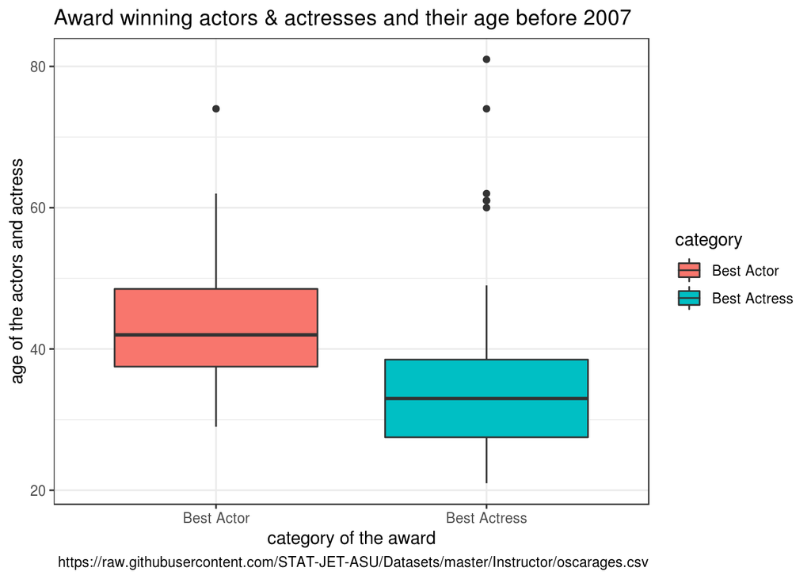

```r
oscarages2007 %>%
  group_by(category) %>%
  ggplot(aes(x = category, y = age)) +
  geom_boxplot(aes(fill = category)) +
  theme_bw() +
  labs(title = "Award winning actors & actresses and their age before 2007",
       x = "category of the award",
       y = "age of the actors and actress",
       caption = "https://raw.githubusercontent.com/STAT-JET-ASU/Datasets/master/Instructor/oscarages.csv")
```

5. Use `facet_grid` create histograms to compare the age distributions of Best Actor and Best Actress winners prior to 2007. Arrange the plots so they are stacked versus side-by-side. Add an informative title, x and y axis labels, a caption that shows the data source.

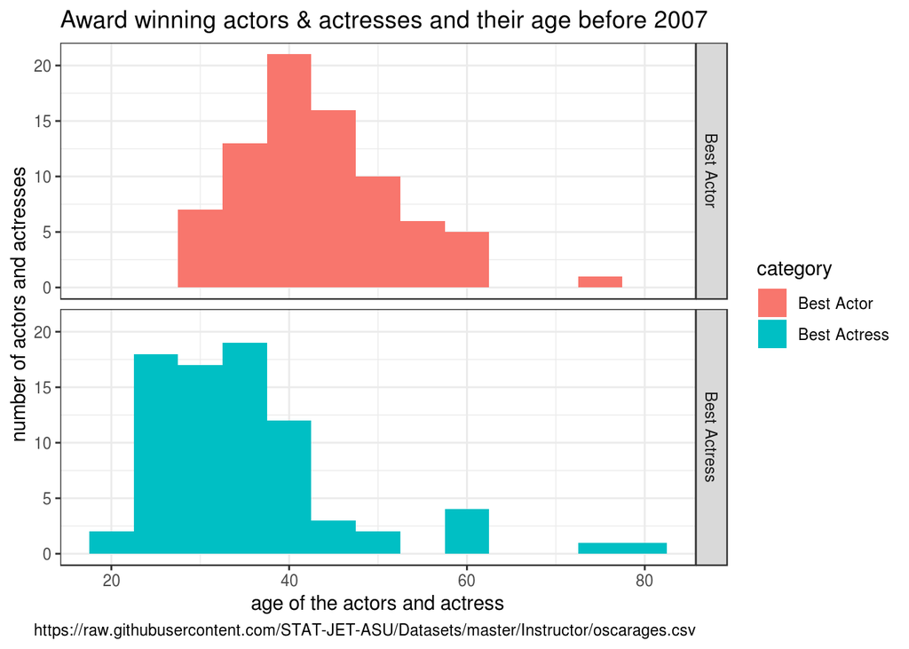

```r
oscarages2007 %>%
  ggplot(aes(x = age)) +
  geom_histogram(aes(fill = category),
                 binwidth = 5) +
  facet_grid(category~.) +
  theme_bw() +
  labs(title = "Award winning actors & actresses and their age before 2007",
       x = "age of the actors and actress",
       y = "number of actors and actresses",
       caption = "https://raw.githubusercontent.com/STAT-JET-ASU/Datasets/master/Instructor/oscarages.csv")
```

6. Which actress actually won the Best Actress Oscar in 2007? How old was she? For what movie did she win? Use the `filter` and `select` functions to display the answer. You’ll need to go back to the full dataset for this.

```r
bestactress2007 <- oscarages %>%
  filter(ceremony == 2007,
         category == "Best Actress") %>%
  select(ceremony, category, name, age)

glimpse(bestactress2007)
```

```
Observations: 1
Variables: 4
$ ceremony <dbl> 2007
$ category <chr> "Best Actress"
$ name     <chr> "Helen Mirren"
$ age      <dbl> 61
```

7. Was the 2007 Best Actress winner an outlier compared to previous Best Actress winners? If she were a man, would she have been an outlier compared to previous Best Actor winners? Determine the answers using code.

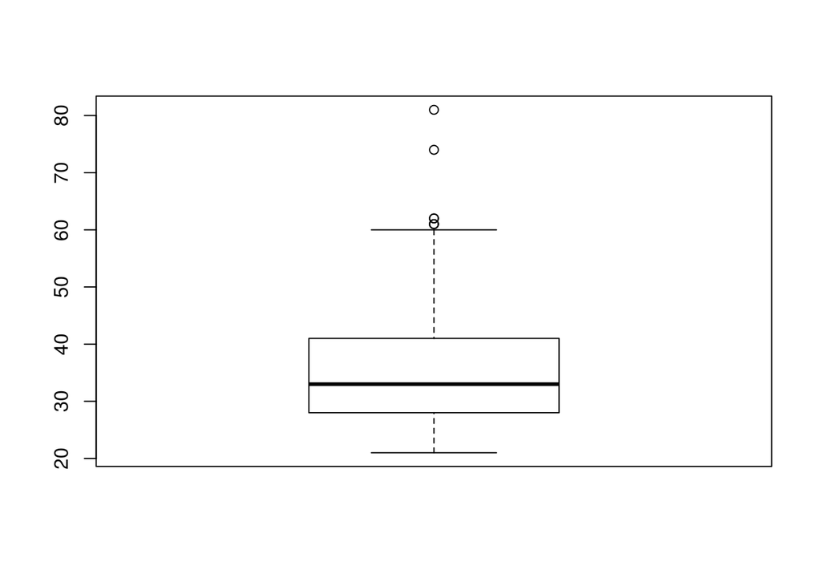

```r
bestactor <- oscarages %>%
  filter(category == "Best Actor")

bestactress <- oscarages %>%
  filter(category == "Best Actress")

# Helen Mirren's age was an outlier
actressoutlier <- boxplot(bestactress$age)$out
```

```r
print(actressoutlier)
```

```
[1] 62 61 74 61 81 61 62
```

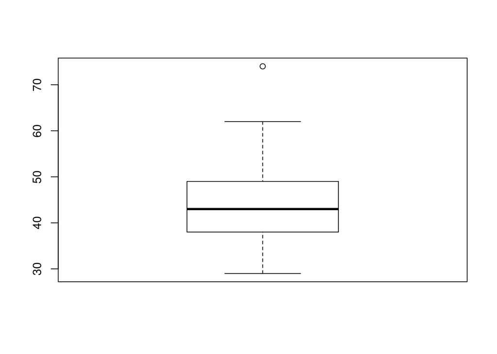

```r
# If she were a man, her age would have not been an outlier
actoroutlier <- boxplot(bestactor$age)$out
```

```r
print(actoroutlier)
```

```
[1] 74
```

8. The 2007 article made several other statements. For example (1) For the last 10 years, the Academy hasn’t awarded a Best Actress Oscar to anyone over 39; (2) For the past nine years, that age limit has hovered even lower, at 35; (3) In fact, if one of our cover subjects wins next month, she’ll become the most mature recipient since 1990, when Jessica Tandy took home the gold for *Driving Miss Daisy*; (4) Since then, only one actress over 50 has won the supporting category, and that was Densch herself, for *Shakespeare in Love* in ’99. Can you verify these statements using code? What are the corresponding values for the Best Actor and Best Supporting Actor categories?

```r
# Best Actress 10 years (1997 - 2007) - 39 years old
bestactress10 <- oscarages %>%
  filter(ceremony >= 1997 & ceremony <= 2007,
         category == "Best Actress",
         age >= 39) %>%
  select(ceremony, category, name, age)
glimpse(bestactress10)
```

```
Observations: 2
Variables: 4
$ ceremony <dbl> 1997, 2007
$ category <chr> "Best Actress", "Best Actress"
$ name     <chr> "Frances McDormand", "Helen Mirren"
$ age      <dbl> 39, 61
```

```r
# Best Actress 9 years (1998 - 2007) - 35 years old
bestactress9 <- oscarages %>%
  filter(ceremony >= 1998 & ceremony <= 2007,
         category == "Best Actress",
         age >= 35) %>%
  select(ceremony, category, name, age)
glimpse(bestactress9)
```

```
Observations: 1
Variables: 4
$ ceremony <dbl> 2007
$ category <chr> "Best Actress"
$ name     <chr> "Helen Mirren"
$ age      <dbl> 61
```

```r
# Best Actress since 1990 years (1990 - 2007) - mature
since1990 <- oscarages %>%
  filter(ceremony >= 1990 & ceremony <= 2007,
         category == "Best Actress",
         age >= 50) %>%
  select(ceremony, category, name, age)
glimpse(since1990)
```

```
Observations: 2
Variables: 4
$ ceremony <dbl> 1990, 2007
$ category <chr> "Best Actress", "Best Actress"
$ name     <chr> "Jessica Tandy", "Helen Mirren"
$ age      <dbl> 81, 61
```

```r
# Supporting Actress over 50 since 1999 (1999 - 2007)
suppActress10 <- oscarages %>%
  filter(ceremony >= 1999 & ceremony <= 2007,
         category == "Supporting Actress",
         age >= 50) %>%
  select(ceremony, category, name, age)
glimpse(suppActress10)
```

```
Observations: 1
Variables: 4
$ ceremony <dbl> 1999
$ category <chr> "Supporting Actress"
$ name     <chr> "Judi Dench"
$ age      <dbl> 64
```

```r
# Best Actor 10 years (1997 - 2007) - 39 years old
bestactor10 <- oscarages %>%
  filter(ceremony >= 1997 & ceremony <= 2007,
         category == "Best Actor",
         age >= 39) %>%
  select(ceremony, category, name, age)
glimpse(bestactor10)
```

```
Observations: 7
Variables: 4
$ ceremony <dbl> 1997, 1998, 1999, 2000, 2002, 2004, 2007
$ category <chr> "Best Actor", "Best Actor", "Best Actor", "Best Actor", "Bes…
$ name     <chr> "Geoffrey Rush", "Jack Nicholson", "Roberto Benigni", "Kevin…
$ age      <dbl> 45, 60, 46, 40, 47, 43, 45
```

```r
# Best Actor 9 years (1998 - 2007) - 35 years old
bestactor9 <- oscarages %>%
  filter(ceremony >= 1998 & ceremony <= 2007,
         category == "Best Actor",
         age >= 35) %>%
  select(ceremony, category, name, age)
glimpse(bestactor9)
```

```
Observations: 9
Variables: 4
$ ceremony <dbl> 1998, 1999, 2000, 2001, 2002, 2004, 2005, 2006, 2007
$ category <chr> "Best Actor", "Best Actor", "Best Actor", "Best Actor", "Bes…
$ name     <chr> "Jack Nicholson", "Roberto Benigni", "Kevin Spacey", "Russel…
$ age      <dbl> 60, 46, 40, 36, 47, 43, 37, 38, 45
```

```r
# Best Actor since 1990 years (1990 - 2007) - mature
since1990man <- oscarages %>%
  filter(ceremony >= 1990 & ceremony <= 2007,
         category == "Best Actor",
         age >= 50) %>%
  select(ceremony, category, name, age)
glimpse(since1990man)
```

```
Observations: 3
Variables: 4
$ ceremony <dbl> 1992, 1993, 1998
$ category <chr> "Best Actor", "Best Actor", "Best Actor"
$ name     <chr> "Anthony Hopkins", "Al Pacino", "Jack Nicholson"
$ age      <dbl> 54, 52, 60
```

```r
# Supporting Actor over 50 since 1999 (1999 - 2007)
suppActor10 <- oscarages %>%
  filter(ceremony >= 1999 & ceremony <= 2007,
         category == "Supporting Actor",
         age >= 50) %>%
  select(ceremony, category, name, age)
glimpse(suppActor10)
```

```
Observations: 6
Variables: 4
$ ceremony <dbl> 1999, 2000, 2002, 2003, 2005, 2007
$ category <chr> "Supporting Actor", "Supporting Actor", "Supporting Actor", …
$ name     <chr> "James Coburn", "Michael Caine", "Jim Broadbent", "Chris Coo…
$ age      <dbl> 70, 67, 52, 51, 67, 72
```